# compscix4152_hw_7.html

## R Markdown

### Exercise 1

### Load the train.csv dataset into R. How many observations and columns are there?

```r
library(tidyverse)
library(broom)
train_data <- read_csv("/Users/dianacuesta/Compscisx-415-2/train.csv")
glimpse(train_data)
```

```
## Observations: 1,460
## Variables: 81
## $ Id            <int> 1, 2, 3, 4, 5, 6, 7, 8, 9, 10, 11, 12, 13, 14, 1...
## $ MSSubClass    <int> 60, 20, 60, 70, 60, 50, 20, 60, 50, 190, 20, 60,...
## $ MSZoning      <chr> "RL", "RL", "RL", "RL", "RL", "RL", "RL", "RL", ...
## $ LotFrontage   <int> 65, 80, 68, 60, 84, 85, 75, NA, 51, 50, 70, 85, ...
## $ LotArea       <int> 8450, 9600, 11250, 9550, 14260, 14115, 10084, 10...
## $ Street        <chr> "Pave", "Pave", "Pave", "Pave", "Pave", "Pave", ...
## $ Alley         <chr> NA, NA, NA, NA, NA, NA, NA, NA, NA, NA, NA, NA, ...
## $ LotShape      <chr> "Reg", "Reg", "IR1", "IR1", "IR1", "IR1", "Reg",...
## $ LandContour   <chr> "Lvl", "Lvl", "Lvl", "Lvl", "Lvl", "Lvl", "Lvl",...
## $ Utilities     <chr> "AllPub", "AllPub", "AllPub", "AllPub", "AllPub"...
## $ LotConfig     <chr> "Inside", "FR2", "Inside", "Corner", "FR2", "Ins...
## $ LandSlope     <chr> "Gtl", "Gtl", "Gtl", "Gtl", "Gtl", "Gtl", "Gtl",...
## $ Neighborhood  <chr> "CollgCr", "Veenker", "CollgCr", "Crawfor", "NoR...
```

[output cut: 68 more lines]

### Exercise 2

Normally at this point you would spend a few days on EDA, but for this homework we will do some very basic EDA and get right to fitting some linear regression models.

Our target will be SalePrice.

### Visualize the distribution of SalePrice.

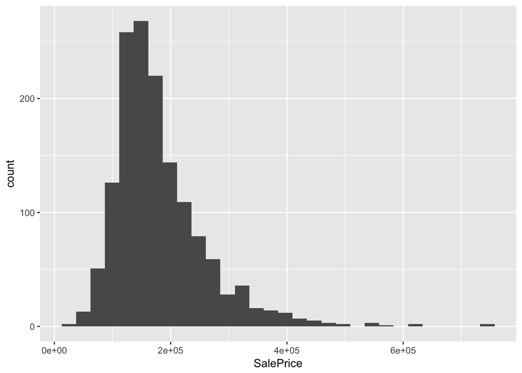

```r
train_data %>% ggplot(aes(x = SalePrice)) +
  geom_histogram()
```

### Visualize the covariation between SalePrice and Neighborhood.

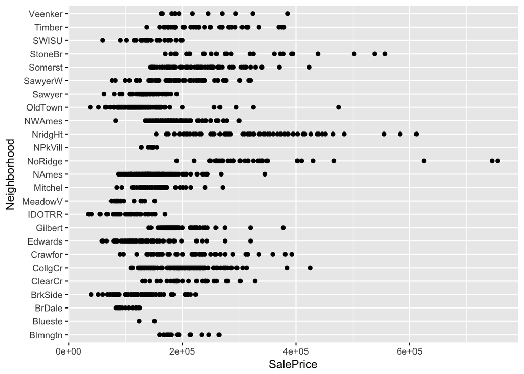

```r
ggplot(train_data, aes(x = SalePrice, y = Neighborhood)) +
  geom_point()
```

### Visualize the covariation between SalePrice and OverallQual.

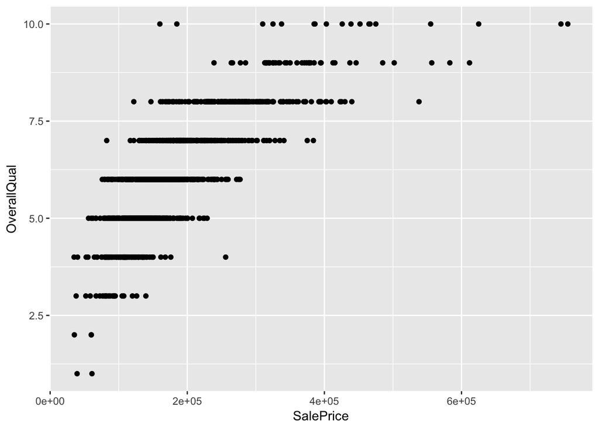

```r
ggplot(train_data, aes(x = SalePrice, y = OverallQual)) +
  geom_point()
```

### Exercise 3

#### Our target is called SalePrice. First, we can fit a simple regression model consisting of only the intercept (the average of SalePrice). Fit the model and then use the broom package to take a look at the coefficient,compare the coefficient to the average value of SalePrice, andtake a look at the R-squared.

```r
library(broom)
lmodel <- lm(SalePrice ~ 1, data = train_data)
tidy(lmodel)
```

```
##          term estimate std.error statistic p.value
## 1 (Intercept) 180921.2  2079.105  87.01877       0
```

```r
glance(lmodel)
```

```
##   r.squared adj.r.squared   sigma statistic p.value df    logLik      AIC
## 1         0             0 79442.5        NA      NA  1 -18544.02 37092.04
##        BIC     deviance df.residual
## 1 37102.62 9.207911e+12        1459
```

### Exercise 4

#### Now fit a linear regression model using GrLivArea, OverallQual, and Neighborhood as the features. Don’t forget to look at data_description.txt to understand what these variables mean. Ask yourself these questions before fitting the model:

```r
Neigh_lm <- lm(formula = SalePrice ~ Neighborhood, data = train_data)
tidy(Neigh_lm)
```

```
##                   term   estimate std.error  statistic      p.value
## 1          (Intercept) 194870.882  13096.68 14.8794092 1.120183e-46
## 2  NeighborhoodBlueste -57370.882  40366.68 -1.4212434 1.554633e-01
## 3   NeighborhoodBrDale -90377.132  18808.68 -4.8050766 1.709171e-06
## 4  NeighborhoodBrkSide -70036.831  14892.85 -4.7027142 2.814264e-06
## 5  NeighborhoodClearCr  17694.546  16603.07  1.0657392 2.867208e-01
## 6  NeighborhoodCollgCr   3094.891  13818.91  0.2239605 8.228199e-01
## 7  NeighborhoodCrawfor  15753.843  15122.75  1.0417317 2.977116e-01
## 8  NeighborhoodEdwards -66651.182  14166.23 -4.7049354 2.784258e-06
## 9  NeighborhoodGilbert  -2016.376  14437.21 -0.1396652 8.889441e-01
## 10  NeighborhoodIDOTRR -94747.099  15821.85 -5.9883701 2.674531e-09
## 11 NeighborhoodMeadowV -96294.412  18521.50 -5.1990599 2.292285e-07
## 12 NeighborhoodMitchel -38600.760  15199.71 -2.5395728 1.120357e-02
## 13   NeighborhoodNAmes -49023.802  13582.44 -3.6093525 3.175155e-04
## 14 NeighborhoodNoRidge 140424.435  15576.98  9.0148676 6.140439e-19
## 15 NeighborhoodNPkVill -52176.438  22260.08 -2.3439468 1.921672e-02
## 16 NeighborhoodNridgHt 121399.741  14470.38  8.3895358 1.152940e-16
## 17  NeighborhoodNWAmes  -5820.814  14541.90 -0.4002788 6.890107e-01
## 18 NeighborhoodOldTown -66645.581  14047.33 -4.7443601 2.300138e-06
## 19  NeighborhoodSawyer -58077.747  14523.33 -3.9989287 6.686878e-05
## 20 NeighborhoodSawyerW  -8315.086  14864.22 -0.5594029 5.759741e-01
## 21 NeighborhoodSomerst  30508.955  14332.79  2.1286128 3.345624e-02
## 22 NeighborhoodStoneBr 115628.118  16975.24  6.8115751 1.415743e-11
## 23   NeighborhoodSWISU -52279.522  16975.24 -3.0797517 2.111064e-03
## 24  NeighborhoodTimber  47376.565  15756.18  3.0068569 2.685524e-03
## 25 NeighborhoodVeenker  43901.845  20895.08  2.1010618 3.580958e-02
```

```r
Ov_lm <- lm(formula = SalePrice ~ GrLivArea, data = train_data)
tidy(Ov_lm)
```

```
##          term   estimate   std.error statistic       p.value
## 1 (Intercept) 18569.0259 4480.754549  4.144174  3.606554e-05
## 2   GrLivArea   107.1304    2.793621 38.348207 4.518034e-223
```

```r
gl_lm <- lm(formula = SalePrice ~ OverallQual, data = train_data)
tidy(gl_lm)
```

```
##          term  estimate std.error statistic       p.value
## 1 (Intercept) -96206.08 5756.4074 -16.71287  1.667971e-57
## 2 OverallQual  45435.80  920.4302  49.36366 2.185675e-313
```

```r
model_mult_lm <- lm(SalePrice ~ GrLivArea + OverallQual + Neighborhood, data = train_data)
tidy(model_mult_lm)
```

```
##                   term    estimate    std.error   statistic      p.value
## 1          (Intercept) -34829.2399 11541.232315 -3.01780945 2.591005e-03
## 2            GrLivArea     55.5645     2.498787 22.23658695 2.375376e-94
## 3          OverallQual  20951.4249  1162.273747 18.02623948 1.238994e-65
## 4  NeighborhoodBlueste -30752.8759 27697.270091 -1.11032155 2.670468e-01
## 5   NeighborhoodBrDale -43358.8812 12978.523255 -3.34081778 8.568095e-04
## 6  NeighborhoodBrkSide -13025.4529 10450.444653 -1.24640179 2.128206e-01
## 7  NeighborhoodClearCr  24575.6351 11569.625542  2.12415129 3.382834e-02
## 8  NeighborhoodCollgCr  11414.3095  9496.581581  1.20193876 2.295858e-01
## 9  NeighborhoodCrawfor  14444.2502 10502.214763  1.37535278 1.692371e-01
## 10 NeighborhoodEdwards -17842.9513  9985.733698 -1.78684430 7.417398e-02
## 11 NeighborhoodGilbert   -892.8796  9954.350137 -0.08969743 9.285402e-01
## 12  NeighborhoodIDOTRR -28178.9866 11135.583978 -2.53053514 1.149517e-02
## 13 NeighborhoodMeadowV -19099.0203 12999.351487 -1.46922870 1.419903e-01
## 14 NeighborhoodMitchel   2030.6121 10555.017277  0.19238359 8.474690e-01
## 15   NeighborhoodNAmes  -4430.0994  9517.290569 -0.46547906 6.416592e-01
## 16 NeighborhoodNoRidge  64642.9895 10939.818250  5.90896375 4.294924e-09
## 17 NeighborhoodNPkVill -17807.1837 15304.007123 -1.16356347 2.447947e-01
## 18 NeighborhoodNridgHt  71587.8398  9994.775058  7.16252635 1.262091e-12
## 19  NeighborhoodNWAmes  -4720.6584 10079.514642 -0.46834183 6.396114e-01
## 20 NeighborhoodOldTown -32080.8775  9863.373223 -3.25252596 1.170466e-03
## 21  NeighborhoodSawyer  -1219.3805 10211.495047 -0.11941254 9.049653e-01
## 22 NeighborhoodSawyerW    303.0986 10264.231736  0.02952960 9.764463e-01
## 23 NeighborhoodSomerst  17766.9637  9829.881193  1.80744440 7.090264e-02
## 24 NeighborhoodStoneBr  69954.4718 11689.508047  5.98438117 2.740136e-09
## 25   NeighborhoodSWISU -36640.1517 11923.592410 -3.07291213 2.159781e-03
## 26  NeighborhoodTimber  29905.8114 10829.232809  2.76158172 5.825641e-03
## 27 NeighborhoodVeenker  47106.8929 14337.857486  3.28549039 1.042655e-03
```

#### What kind of relationship will these features have with our target?

Depending the overal conditions of the materials and the number of feet above the ground the house has the price sale can increase of decrease ###Can the relationship be estimated linearly? no ###Are these good features, given the problem we are trying to solve? I don’t think these features are the best features to resolve the problem

Answer these questions: ####How would you interpret the coefficients on GrLivArea and OverallQual? Overallqual is a better predictor of the price sale thatn GRLivArea

### Are the features practically significant?

Yes, they are practically significant. Specially Neighborhood

### Is the model a good fit?

No, it is not.

### Exercise 6

#### One downside of the linear model is that it is sensitive to unusual values because the distance incorporates a squared term. Fit a linear model to the simulated data below (use y as the target and x as the feature), and look at the resulting coefficients and R-squared. Rerun it about 5-6 times to generate different simulated datasets. What do you notice about the model’s coefficient on x and the R-squared values?

## They change every time we run the model.

```r
sim1a <- tibble(
  x = rep(1:10, each = 3),
  y = x * 1.5 + 6 + rt(length(x), df = 2)
)


slopes <- rep(NA, 5) # empty vector for saving coefficients
for(i in 1:7) {
  samp <- sim1a %>% sample_n(5)
  samp_lm <- lm(x ~ y, data = samp)

  slopes[i] <- coef(samp_lm)[2] # store the coefficient
}
slopes <- as_tibble(slopes)
slopes
```

```
## # A tibble: 7 x 1
##   value
##   <dbl>
## 1 0.617
## 2 0.472
## 3 0.441
## 4 0.334
## 5 0.678
## 6 0.626
## 7 0.660
```